# Fine-scale heterogeneity in Schistosoma mansoni force of infection measured through antibody response

Figure 4c, Figure S3 seroprevalence and force of infection by age

Ben Arnold ben.arnold@ucsf.edu

run 2020-04-10 15:24:49

# Preamble

```r
library(here)
here()
```

```
## [1] "/Users/benarnold/mbita-schisto"
```

```r
#--------------------------------
# source the configuration file
# and the shared functions file
#--------------------------------
source(here("R/mbita-schisto-Config.R"))
source(here("R/mbita-schisto-Functions.R"))
```

# Load Mbita Kenya antibody measurements

These data include measurements from pre-school aged children in 30 villages near Homa Bay and Mbita in Western Kenya. This article summarizes the study design and field methods:

Won KY, Kanyi HM, Mwende FM, Wiegand RE, Brook Goodhew E, Priest JW, et al. Multiplex Serologic Assessment of Schistosomiasis in Western Kenya: Antibody Responses in Preschool Age Children as a Measure of Reduced Transmission. *Am J Trop Med Hyg.* 2017; 16–0665. https://www.ncbi.nlm.nih.gov/pubmed/28719280

```r
#-----------------------------------
# load the child antibody and
# kato-katz measurements
#-----------------------------------
d <- readRDS(here("data","mbita_schisto.rds"))

#-----------------------------------
# load the village-level spatial
# covariate data, created with
# mbita-schisto-map.Rmd
#
# note: for public-facing workflow
# this file does not include village
# lon/lat to protect participant
# confidentiality
#-----------------------------------
d_spatial <- readRDS(here("data","mbita_spatial.rds"))

d2 <- d %>%
  left_join(d_spatial,by="vid")

# create age strata
# create log values for SEA MFI and KK epg
# convert the dist_victoria variable from class units to numeric
d2 <- d2 %>%
  mutate(agecat = cut(agey,breaks=c(0,1,2,3,4,6),
                      labels=c("<1 year","1 year","2 years","3 years","4 years")),
         logsea = log10(sea),
         logepg = log10(sm_epg),
         dist_victoria = as.numeric(dist_victoria)
         )

#----------------------------------
# prep data for model
#----------------------------------
d3 <- d2 %>%
  ungroup() %>%
  mutate(vid=factor(vid),
         dummy=1)
```

# Age stratified distributions

```r
table(d2$agecat)
```

```
##
## <1 year  1 year 2 years 3 years 4 years
##      51     570     780     890    1372
```

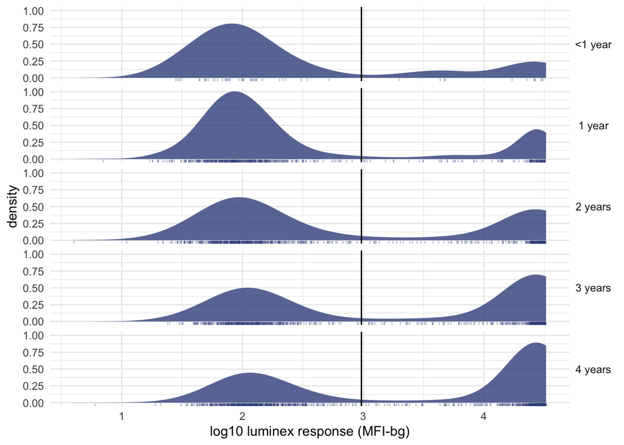

```r
pdist <- ggplot(data=d2,aes(x=logsea)) +
  facet_grid(agecat~.) +
  geom_density(alpha=0.8,color=NA,fill=vircols[3]) +
  geom_rug(alpha=0.3,color = vircols[3]) +
  geom_vline(aes(xintercept = log10(965) ),lty=1) +
  # scale_fill_manual(values=pcols)+
  # geom_vline(aes(xintercept = mixcut),lty=2) +
  labs(x="log10 luminex response (MFI-bg)") +
  theme_minimal() +
  theme(legend.position = "none",
        strip.text.y=element_text(angle=0))

pdist
```

```r
# save png file for presentation
# ggsave(filename=here("output","mbita-ab-dists-ashb-sea-vsp.png"),plot=pdist2,device="png",width=8,height=7)
```

# Age dependent seroprevalence

Estimate age-dependent seroprevalence using a semi-parametric spline fit. Include community-level random effects to account for repeated measures within community. Estimate an approximate, simultaneous 95% confidence interval on the spline fit.

```r
fitp_sea <- mgcv::gam(sea_pos~s(agey,bs="cr",k=9) + s(vid,bs="re",by=dummy), family="binomial",
                      data=d3)
newd <- d3 %>%  mutate(dummy=0)
fitp_seaci <- gamCI(m=fitp_sea,newdata=newd,nreps=10000)

# convert linear predictor to prevalance
fitp_seaci <- fitp_seaci %>%
  mutate(fit = expitfn(fit),
         uprP = expitfn(uprP),
         lwrP = expitfn(lwrP),
         uprS = expitfn(uprS),
         lwrS = expitfn(lwrS),
         )
```

Make a figure

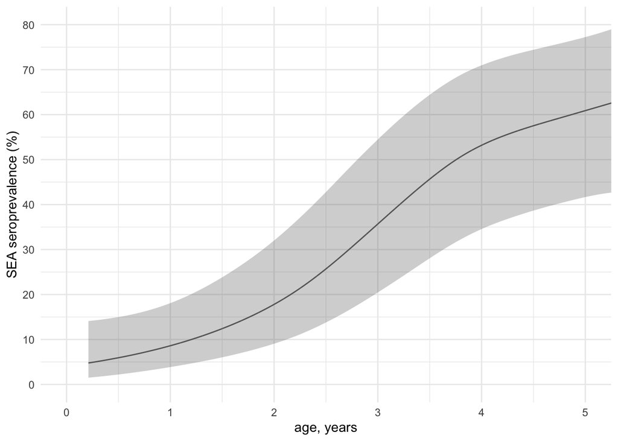

```r
pageprev <- ggplot(data=fitp_seaci,aes(x=agey,y=fit)) +
  geom_ribbon(aes(ymin=lwrS,ymax=uprS),alpha=0.3,fill="gray40") +
  geom_line(lwd=0.5,alpha=1,color="gray40") +
  scale_y_continuous(breaks=seq(0,0.8,by=0.1),labels=seq(0,80,by=10))+
  labs(x="age, years",y="SEA seroprevalence (%)") +
  coord_cartesian(xlim=c(0,5),ylim=c(0,0.8))+
  theme_minimal() +
  theme(legend.position="none")

pageprev
```

# Age-specific force of infection (FOI)

Estimate the age-dependent seroconversion rate as a measure of force of infection (FOI) using a semi-parametric spline model. Estimate FOI using finite differences of the age-dependent seroprevalence curve for the derivative.

```r
#----------------------------
# function to estimate the
# age-specific FOI under a
# GAM model smooth
#
# @param       m : GAM model fit object from mgcv gam()
# @param newdata : data.frame on which to make predictions from the model fit.
#                  Must include all variables used to fit the model m
# @param  fdvar  : Finite difference variable (string), included in newdata which should be used
#                  to estimate the derivative.
# @param    eps  : amount to shift fdvar for calculating finite differences
# @param  level  : confidence level for simultaneous confidence intervals
# @param  nreps  : number of replications to sample from the Bayesian posterior
#
# @returns : foiCI returns a data.frame identical to newdata with 13 new variables:
#            foi : pointwise estimate of the force of infection
#         foi_se : approximate standard error of the FOI prediction
#      foi_uprBS : upper pointwise 95% confidence interval from the posterior bootstrap simulation
#      foi_lwrBS : lower pointwise 95% confidence interval from the posterior bootstrap simulation
#       foi_crit : critical value used for teh simultaneous CI calculation
#       foi_uprP : upper pointwise 95% confidence interval
#       foi_lwrP : lower pointwise 95% confidence interval
#       foi_uprS : upper simultaneous 95% confidence interval
#       foi_lwrS : lower simultaneous 95% confidence interval
#             ft : pointwise estimate of the derivative of Ft
#          ft_se : pointwise estimate of the standard error of the derivative of Ft
#             Ft : pointwise estimate of the linear predictor of Ft
#          Ft_se : pointwise estimate of the standard error of the linear predictor of Ft
#
#                    Note: foi = ft * (exp(Ft)/(1+exp(Ft))) for a logit link
#                    See Hens et al. 2012 Modeling Infectious Disease Parameters
#                                         Using Serological and Social Contact Data, Table 5.1
#----------------------------
foiCI <- function(m,newdata,fdvar,eps=1e-07,level=0.95,nreps=10000) {

  # variance-covariance matrix from the spline fit
  # unconditional on the fit of the mean
  # this is slightly more conservative and with better coverage
  # properties.
  # See Marra G, Wood SN.
  # Coverage Properties of Confidence Intervals
  # for Generalized Additive Model Components.
  # Scand Stat Theory Appl. 2012;39: 53–74.
  Vb <- vcov(m,unconditional = TRUE)

  # calculate the linear predictor, g(Ft), and its pointwise SE
  pred <- predict(m, newdata, se.fit = TRUE)
  Ft <- pred$fit
  Ft_se <- pred$se.fit

  # simulate from the posterior distrivbution
  # with mean zero and variance from the posterior
  # assuming multivariate normal coefficients
  BUdiff <- MASS::mvrnorm(n = nreps, mu = rep(0, nrow(Vb)), Sigma = Vb)

  # get a critical value for the
  # simultaneous confidence interval of g(Ft)
  X0 <- predict(m, newdata, type = "lpmatrix")
  Ft_simDev <- X0 %*% t(BUdiff)
  Ft_absDev <- abs(sweep(Ft_simDev, 1, Ft_se, FUN = "/"))
  Ft_masd <- apply(Ft_absDev, 2L, max)
  Ft_crit <- quantile(Ft_masd, prob = 0.95, type = 8)

  # calculate the derivative, g'(Ft), using
  # finite differences and its pointwise SE
  # ?mgcv::predict.gam includes an example of this
  newdata2 <- newdata
    newdata2[fdvar] <- newdata[fdvar]+eps
  X1 <- predict(m,newdata2,type='lpmatrix')
  Xp <- (X1 - X0) / eps
  ft <- Xp %*% coef(m)
  ft_se <- rowSums(Xp %*% Vb * Xp)^0.5

  # get a critical value for the
  # simultaneous confidence interval of the derivative
  ft_simDev <- Xp %*% t(BUdiff)
  ft_absDev <- abs(sweep(ft_simDev, 1, ft_se, FUN = "/"))
  ft_masd <- apply(ft_absDev, 2L, max)
  ft_crit <- quantile(ft_masd, prob = level, type = 8)

  # parametric bootstrap simulation from the
  # model coefficient estimates, assuming the model is true
  # FOI is the derivative of the linear predictor
  # multiplied by the predicted probability, Ft
  sims<- MASS::mvrnorm(n = nreps, mu = coef(m), Sigma = Vb)
  Ft_bs <- X0 %*% t(sims)
  ft_bs <- Xp %*% t(sims)
  foi_bs <- ft_bs*(exp(Ft_bs)/(1+exp(Ft_bs)))

  # estimate age-specific force of infection
  # averaged over the bootstrap replicates
  # along with SE and confidence intervals for FOI
  # use whichever critical value is larger for Ft or ft
  # for the simultaneous CIs
  foi <- rowMeans(foi_bs)
  foi_crit <- max(Ft_crit,ft_crit)
  foi_se <- apply(foi_bs,1,function(x) sd(x))
  foi_lwrBS <- apply(foi_bs,1,function(x) quantile(x,probs=c(0.025)))
  foi_uprBS <- apply(foi_bs,1,function(x) quantile(x,probs=c(0.975)))
  foi_Sci <- cbind(foi - foi_crit*foi_se, foi + foi_crit*foi_se)

  # return results
  pred <- data.frame(newdata,foi=foi,foi_se=foi_se,foi_lwrBS=foi_lwrBS,foi_uprBS=foi_uprBS,foi_crit,ft=ft,ft_se=ft_se,Ft=Ft,Ft_se=Ft_se)
  pred <- mutate(pred,
                 foi_uprP = foi + (2 * foi_se),
                 foi_lwrP = foi - (2 * foi_se),
                 foi_uprS = foi + (foi_crit * foi_se),
                 foi_lwrS = foi - (foi_crit * foi_se)
  )
  return(pred)

}
```

```r
#----------------------------
# estimate FOI for SEA
# from the spline model
#----------------------------

#----------------------------------------
# Model predictions of FOI, with age grid newd
#----------------------------------------
set.seed(123)
newd <- data.frame(agey=seq(0.2,5,by=0.01),vid="1",dummy=0)
foi_ests <- foiCI(m=fitp_sea,newdata=newd,fdvar="agey")
```

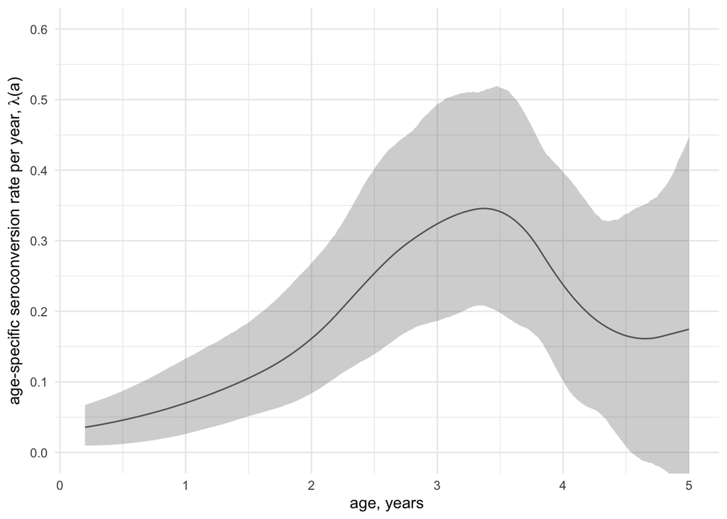

```r
foiplot <- ggplot(data=foi_ests,aes(x=agey,y=foi,ymin=foi_lwrBS,ymax=foi_uprBS)) +
  geom_ribbon(color=NA,alpha=0.3,fill="gray40") +
  geom_line(color="gray40") +
  scale_y_continuous(breaks=seq(0,0.6,by=0.1))+
  labs(x="age, years",y=expression(paste("age-specific seroconversion rate per year, ",lambda,"(a)")))+
  coord_cartesian(ylim=c(0,0.6))+
  theme_minimal()
foiplot
```

# Figure 4c Analyses stratified by distance

In the descriptive analyses, most villages further than 1.5 km of Lake Victoria had distinctly lower village-specific estimates of force of infection. Stratify the age-seroprevalence curves and age-specific force of infection estimates by distance from the lake.

## Fit a stratified seroprevalence model

```r
#-----------------------------
# create an indicator for
# children living in villages
# more than 1500 meters from
# lake victoria.  This distance
# was chosen by inspection of
# village-specific FOI estimates
#-----------------------------
d4 <- d3 %>%
  mutate(gt15 = ifelse(dist_victoria>1500,1,0),
         lt15 = ifelse(dist_victoria<=1500,1,0)
         )

#----------------------------------------
# fit a model allowing age-specific
# seroprevalence to vary by group
#----------------------------------------
fitp_dist <- mgcv::gam(sea_pos~s(agey,bs="cr",k=9,by=gt15) +
                         s(agey,bs="cr",k=9,by=lt15) +
                         s(vid,bs="re",by=dummy),
                       family="binomial",
                       data=d4)
newd0 <- d4 %>%  mutate(dummy=0,gt15=0,lt15=1)
newd1 <- d4 %>%  mutate(dummy=0,gt15=1,lt15=0)
fitp_dist0_ci <- gamCI(m=fitp_dist,newdata=newd0,nreps=10000)
fitp_dist1_ci <- gamCI(m=fitp_dist,newdata=newd1,nreps=10000)

# convert linear predictor to prevalance
fitp_dist_ci <- bind_rows(fitp_dist0_ci,fitp_dist1_ci) %>%
  mutate(fit = expitfn(fit),
         uprP = expitfn(uprP),
         lwrP = expitfn(lwrP),
         uprS = expitfn(uprS),
         lwrS = expitfn(lwrS),
         ) %>%
  mutate(dist=factor(gt15,levels=c(0,1),labels=c("<1.5 km from lake",">1.5 km from lake")))
```

## Figure of seroprevalence by age, stratified by distance from the lake

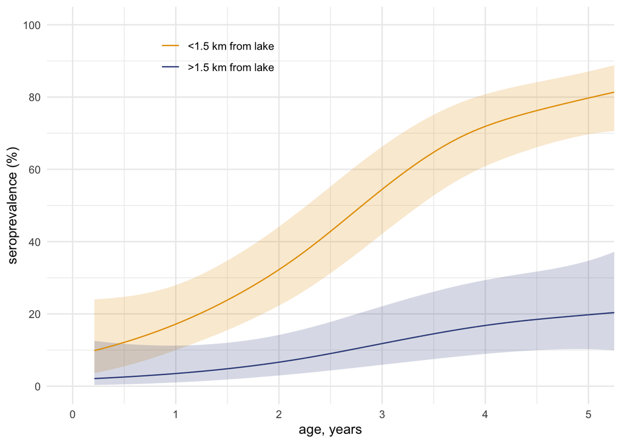

```r
#----------------------------------------
# seroprevalence curves
#----------------------------------------
distcols <- c(cbPalette[c(2)],vircols[3])
pageprev_sea01 <- ggplot(data=fitp_dist_ci,aes(x=agey,y=fit,group=dist,color=dist,fill=dist)) +
  geom_ribbon(aes(ymin=lwrS,ymax=uprS),alpha=0.2,color=NA) +
  geom_line(lwd=0.5,alpha=1) +
  scale_color_manual(values=distcols,guide=guide_legend(title=""))+
  scale_fill_manual(values=distcols,guide=FALSE)+
  scale_y_continuous(breaks=seq(0,1,by=0.2),labels=seq(0,100,by=20))+
  labs(x="age, years",y="seroprevalence (%)") +
  coord_cartesian(ylim=c(0,1),xlim=c(0,5))+
  theme_minimal() +
  theme(legend.position=c(0.3,0.9))

pageprev_sea01
```

```r
# save png file
ggsave(filename=here("output","mbita-sea-age-seroprev-dist.png"),plot=pageprev_sea01,device="png",width=3*1.18,height=3)
```

## Estimate FOI, stratified by distance from the lake

```r
#----------------------------------------
# Conditional estimates of FOI
#----------------------------------------
set.seed(123)
newd0 <- data.frame(agey=seq(0.2,5,by=0.01),gt15=0,lt15=1,vid="1",dummy=0)
newd1 <- data.frame(agey=seq(0.2,5,by=0.01),gt15=1,lt15=0,vid="1",dummy=0)
foi_ests0 <- foiCI(m=fitp_dist,newdata=newd0,fdvar="agey")
foi_ests1 <- foiCI(m=fitp_dist,newdata=newd1,fdvar="agey")
foi_dist <- bind_rows(foi_ests0,foi_ests1) %>%
  mutate(dist=factor(gt15,levels=c(0,1),labels=c("<1.5 km from lake",">1.5 km from lake")))
```

## Figure of FOI by age, stratified by distance from the lake

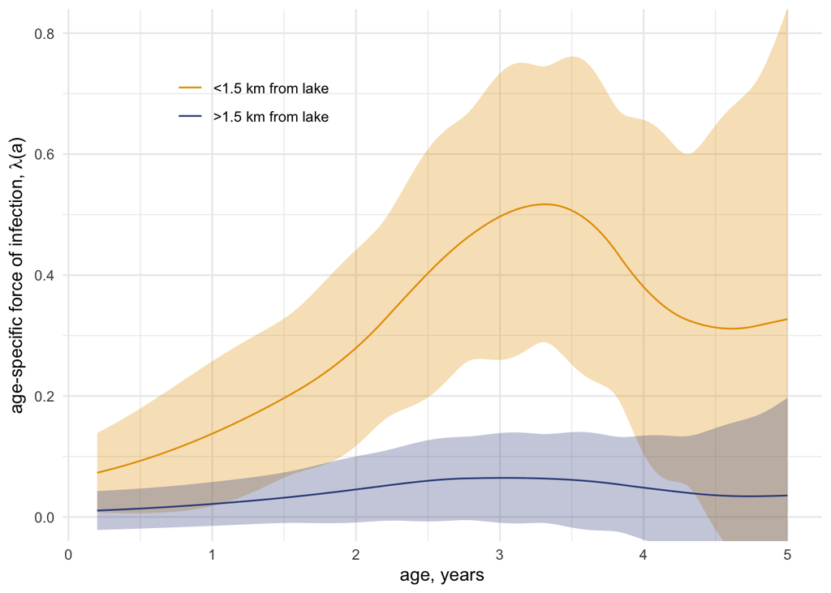

```r
#----------------------------------------
# FOI curves
#----------------------------------------
foiplot2 <- ggplot(data=foi_dist,aes(x=agey,y=foi,ymin=foi_lwrS,ymax=foi_uprS,group=dist,color=dist,fill=dist)) +
  # approximate simultaneous 95% CI
  geom_ribbon(color=NA,alpha=0.3) +
  # spline fits
  geom_line() +
  scale_color_manual(values=distcols,guide=guide_legend(title=""))+
  scale_fill_manual(values=distcols,guide=FALSE)+
  scale_y_continuous(breaks=seq(0,0.8,by=0.2))+
  labs(x="age, years",y=expression(paste("age-specific force of infection, ",lambda,"(a)"))) +
  coord_cartesian(ylim=c(0,0.8))+
  theme_minimal() +
    theme(legend.position=c(0.25,0.85))
foiplot2
```

```r
# save png file
ggsave(filename=here("output","mbita-sea-age-foi-dist.png"),plot=foiplot2,device="png",width=3*1.18,height=3)
```

# Supplementary Figure 3

Sensitivity analysis of distance ranges

Stratify the 30 villages into qunitiles of distance and repeat the age-dependent analyses

## Separate communities into 5 groups by quintiles of distance

```r
#----------------------------------------
# Identify distance qunitiles
#----------------------------------------
dvil <- d4 %>%
  group_by(vid) %>%
  slice(1) %>%
  dplyr::select(vid,dist_victoria)

dist_qs <- quantile(dvil$dist_victoria,probs=seq(0,1,by=0.2))

dist_cat <- dvil %>%
  mutate(distq = cut(dist_victoria,breaks=c(0,dist_qs[2:5],10000),labels=FALSE)) %>%
  dplyr::select(vid,distq) %>%
  mutate(distq=factor(distq,levels=1:5,labels=paste0("Q",1:5)))
```

## Fit a stratified seroprevalence model by quntiles

```r
#-----------------------------
# create indicators for
# children living in qunitiles
# of distance from lake victoria.
#-----------------------------
d5 <- d4 %>%
  left_join(dist_cat,by="vid") %>%
  mutate(dq1 = ifelse(distq=="Q1",1,0),
         dq2 = ifelse(distq=="Q2",1,0),
         dq3 = ifelse(distq=="Q3",1,0),
         dq4 = ifelse(distq=="Q4",1,0),
         dq5 = ifelse(distq=="Q5",1,0),
         )

#----------------------------------------
# fit a model allowing age-specific
# seroprevalence to vary by group
#----------------------------------------
fitp_distq <- mgcv::gam(sea_pos~s(agey,bs="cr",k=5,by=dq1) +
                          s(agey,bs="cr",k=5,by=dq2) +
                          s(agey,bs="cr",k=5,by=dq3) +
                          s(agey,bs="cr",k=5,by=dq4) +
                          s(agey,bs="cr",k=5,by=dq5) +
                          s(vid,bs="re",by=dummy),
                       family="binomial",
                       data=d5)

#----------------------------------------
# prediction datasets with distance set to each quintile
#----------------------------------------
newd1 <- d5 %>%  mutate(dummy=0,dq1=1,dq2=0,dq3=0,dq4=0,dq5=0)
newd2 <- d5 %>%  mutate(dummy=0,dq1=0,dq2=1,dq3=0,dq4=0,dq5=0)
newd3 <- d5 %>%  mutate(dummy=0,dq1=0,dq2=0,dq3=1,dq4=0,dq5=0)
newd4 <- d5 %>%  mutate(dummy=0,dq1=0,dq2=0,dq3=0,dq4=1,dq5=0)
newd5 <- d5 %>%  mutate(dummy=0,dq1=0,dq2=0,dq3=0,dq4=0,dq5=1)

#----------------------------------------
# estimate fitted values and simultaneous 95% CIs for each
# distance qunitile. Note, all curves are age-standardized across
# the entire study population
#----------------------------------------
fitp_distq1_ci <- gamCI(m=fitp_distq,newdata=newd1,nreps=10000)
fitp_distq2_ci <- gamCI(m=fitp_distq,newdata=newd2,nreps=10000)
fitp_distq3_ci <- gamCI(m=fitp_distq,newdata=newd3,nreps=10000)
fitp_distq4_ci <- gamCI(m=fitp_distq,newdata=newd4,nreps=10000)
fitp_distq5_ci <- gamCI(m=fitp_distq,newdata=newd5,nreps=10000)

#----------------------------------------
# convert linear predictor to prevalance
#----------------------------------------
fitp_distq_ci <- bind_rows(fitp_distq1_ci,fitp_distq2_ci,fitp_distq3_ci,fitp_distq4_ci,fitp_distq5_ci) %>%
  mutate(fit = expitfn(fit),
         uprP = expitfn(uprP),
         lwrP = expitfn(lwrP),
         uprS = expitfn(uprS),
         lwrS = expitfn(lwrS),
         )

#----------------------------------------
# format distance qunitile variable
# for plotting
#----------------------------------------
dist_qs_labs <- c(
  paste0("Q1: (",sprintf("%1.0f",dist_qs[1])," - ",sprintf("%1.0f",dist_qs[2]),"]"),
  paste0("Q2: (",sprintf("%1.0f",dist_qs[2])," - ",sprintf("%1.0f",dist_qs[3]),"]"),
  paste0("Q3: (",sprintf("%1.0f",dist_qs[3])," - ",sprintf("%1.0f",dist_qs[4]),"]"),
  paste0("Q4: (",sprintf("%1.0f",dist_qs[4])," - ",sprintf("%1.0f",dist_qs[5]),"]"),
  paste0("Q5: (",sprintf("%1.0f",dist_qs[4])," - ",sprintf("%1.0f",max(dvil$dist_victoria)),"]")
)

fitp_distq_ci <- fitp_distq_ci %>%
    mutate(distq = NA,
         distq = ifelse(dq1 == 1,dist_qs_labs[1],distq),
         distq = ifelse(dq2 == 1,dist_qs_labs[2],distq),
         distq = ifelse(dq3 == 1,dist_qs_labs[3],distq),
         distq = ifelse(dq4 == 1,dist_qs_labs[4],distq),
         distq = ifelse(dq5 == 1,dist_qs_labs[5],distq)
  )
```

## Figure of seroprevalence by age, stratified by distance quintiles

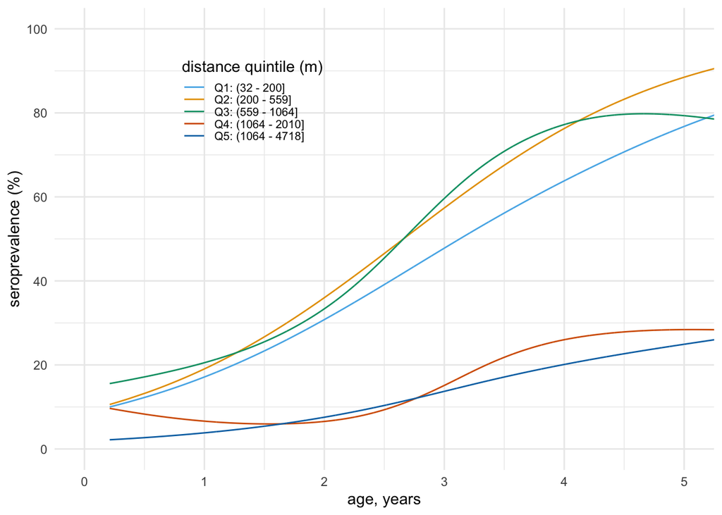

```r
#----------------------------------------
# seroprevalence curves
#----------------------------------------
distqcols <- cbPalette[c(3,2,4,7,6)]
pageprev_sea_distq <- ggplot(data=fitp_distq_ci,aes(x=agey,y=fit,group=distq,color=distq,fill=distq)) +
  # geom_ribbon(aes(ymin=lwrS,ymax=uprS),alpha=0.2,color=NA) +
  geom_line(lwd=0.5,alpha=1) +
  scale_color_manual(values=distqcols,guide=guide_legend(title="distance quintile (m)"))+
  scale_fill_manual(values=distqcols,guide=FALSE)+
  scale_y_continuous(breaks=seq(0,1,by=0.2),labels=seq(0,100,by=20))+
  labs(x="age, years",y="seroprevalence (%)") +
  coord_cartesian(ylim=c(0,1),xlim=c(0,5))+
  theme_minimal() +
  theme(legend.position=c(0.3,0.8),
        legend.text = element_text(size=8),
        legend.key.height= unit(0.3,units="cm"))

pageprev_sea_distq
```

```r
# save png file
ggsave(filename=here("output","mbita-sea-age-seroprev-distq.png"),plot=pageprev_sea_distq,device="png",width=3*1.18,height=3)
```